# Maps

Module 10

Ray J. Hoobler

## Libraries

```r
library(tidyverse)
library(patchwork)
library(maps) # Original maps package (mostly outdated, but can still be used for simple maps)
library(usmap) # US map that includes Alaska and Hawaii
library(mapdata) # Extra map databases (supplment to maps package; world map is out-dated)
library(ggmap) # Allows use of Stamen and Google maps with ggplot2
library(sf) # Simple Features for R (modern way to work with spatial data)
```

## Simple Maps (1/2)

### Getting started with the `maps` package

```r
map("state") # US state map (lower 48)
```

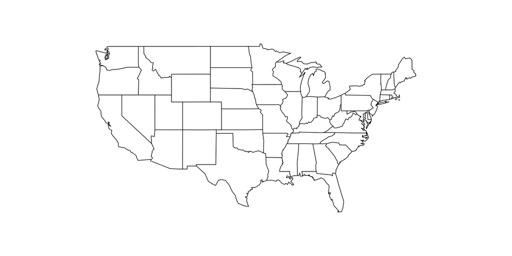

## Simple Maps (2/2)

```r
map(database = "world", regions = ".", exact = FALSE, boundary = TRUE,
  interior = TRUE, projection = "", parameters = NULL, orientation = NULL,
  fill = FALSE, col = 1, plot = TRUE, add = FALSE, namesonly = FALSE,
  xlim = NULL, ylim = NULL, wrap = FALSE, resolution = if (plot) 1 else 0,
  type = "l", bg = par("bg"), mar = c(4.1, 4.1, par("mar")[3], 0.1),
  myborder = 0.01, namefield="name", lforce="n", ...)
```

## Using Data from the `maps` Package in `ggplot2` (1/3)

### Create a data frame from the `maps` package databases

```r
us_states <- map_data("state")
us_states
```

|  | long | lat | group | order | region | subregion |
| --- | --- | --- | --- | --- | --- | --- |
| 1 | -87.46201 | 30.38968 | 1 | 1 | alabama | NA |
| 2 | -87.48493 | 30.37249 | 1 | 2 | alabama | NA |
| 3 | -87.52503 | 30.37249 | 1 | 3 | alabama | NA |
| 4 | -87.53076 | 30.33239 | 1 | 4 | alabama | NA |
| 5 | -87.57087 | 30.32665 | 1 | 5 | alabama | NA |
| 6 | -87.58806 | 30.32665 | 1 | 6 | alabama | NA |
| 7 | -87.59379 | 30.30947 | 1 | 7 | alabama | NA |
| 8 | -87.59379 | 30.28655 | 1 | 8 | alabama | NA |
| 9 | -87.67400 | 30.27509 | 1 | 9 | alabama | NA |
| 10 | -87.81152 | 30.25790 | 1 | 10 | alabama | NA |

[output cut: 9990 more lines]

## Using Data from the `maps` Package in `ggplot2` (2/3)

### Create a map of the US states using `ggplot2`

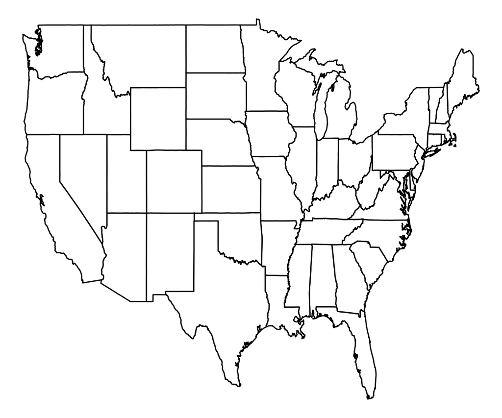

```r
ggplot(us_states, aes(x = long, y = lat, group = group)) + # make sure to include "group" in the aesthetics
  geom_polygon(fill = "white", color = "black") + # borders on the map are just a collection of polygons; each polygon is a group
  theme_void()
```

**The scaling is off as ggplot does not know how to scale the map.**

## Using Data from the `maps` Package in `ggplot2` (3/3)

### Two solutions for scaling the map

#### 1. Use the `coord_fixed()` function

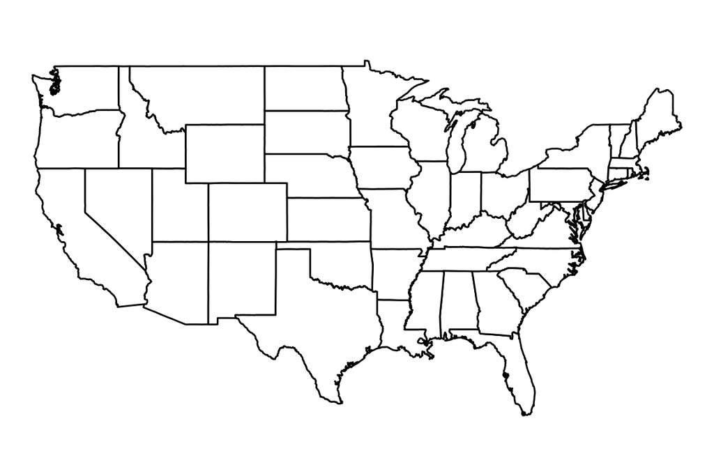

```r
ggplot(us_states, aes(x = long, y = lat, group = group)) +
  geom_polygon(fill = "white", color = "black") +
  theme_void() +
  coord_fixed(1.3)
```

#### 2. Use the `coord_map()` function

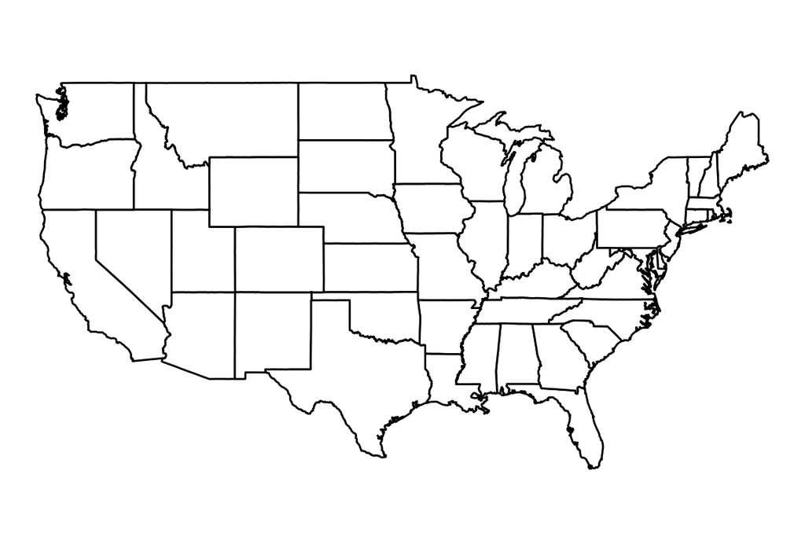

```r
ggplot(us_states, aes(x = long, y = lat, group = group)) +
  geom_polygon(fill = "white", color = "black") +
  theme_void() +
  coord_map()
```

## Add Cities to the Map (1/4)

### Create a data frame of cities in the US usign the `us.cities` data set

```r
us_cities <- as_tibble(us.cities)
us_cities
```

| name | country.etc | pop | lat | long | capital |
| --- | --- | --- | --- | --- | --- |
| Abilene TX | TX | 113888 | 32.45 | -99.74 | 0 |
| Akron OH | OH | 206634 | 41.08 | -81.52 | 0 |
| Alameda CA | CA | 70069 | 37.77 | -122.26 | 0 |
| Albany GA | GA | 75510 | 31.58 | -84.18 | 0 |
| Albany NY | NY | 93576 | 42.67 | -73.80 | 2 |
| Albany OR | OR | 45535 | 44.62 | -123.09 | 0 |
| Albuquerque NM | NM | 494962 | 35.12 | -106.62 | 0 |
| Alexandria LA | LA | 44933 | 31.29 | -92.46 | 0 |
| Alexandria VA | VA | 127159 | 38.82 | -77.09 | 0 |
| Alhambra CA | CA | 88857 | 34.08 | -118.13 | 0 |

[output cut: 995 more lines]

## Add Cities to the Map (2/4)

### Create a map of the US states with cities using `ggplot2`

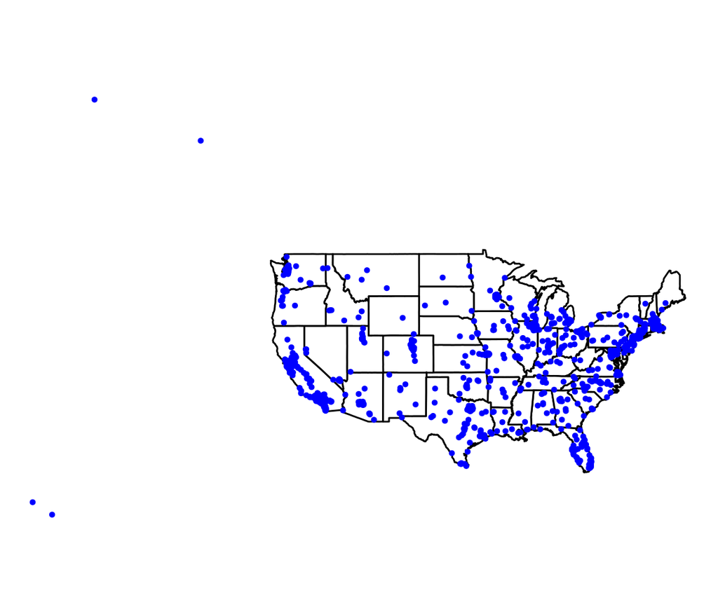

```r
us_states |>
  ggplot(aes(x = long, y = lat)) +
  geom_polygon(aes(group = group), fill = "white", color = "black") +
  geom_point(data = us_cities, aes(x = long, y = lat), color = "blue", size = 1) +
  theme_void() +
  coord_map()
```

## Add Cities to the Map (3/4)

### What’s a quick way to remove Alaska and Hawaii cities from the map?

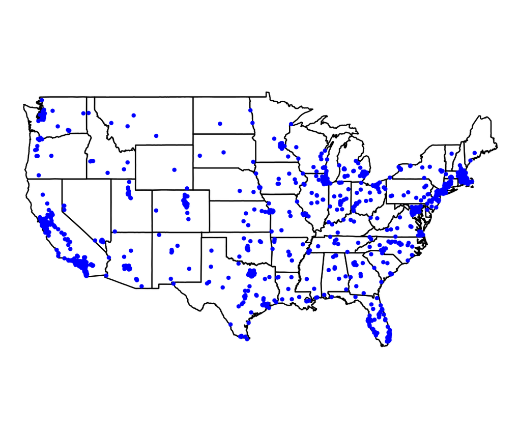

```r
cities_lower48 <- us_cities |>
  filter(!(country.etc %in% c("AK", "HI")))

us_states |>
  ggplot(aes(x = long, y = lat)) +
  geom_polygon(aes(group = group), fill = "white", color = "black") +
  geom_point(data = cities_lower48, aes(x = long, y = lat), color = "blue", size = 1) +
  theme_void() +
  coord_map()
```

## Add Cities to the Map (4/4)

### Add state capitals and the national capital as unique points

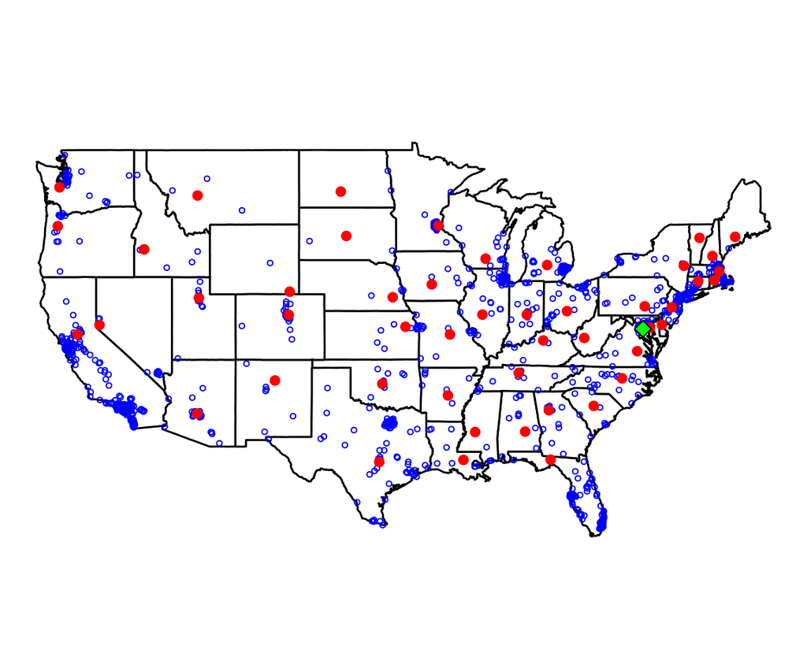

```r
state_capitals <- cities_lower48 |>
  filter(capital == 2)

us_capital <- us_cities |>
  filter(name == "WASHINGTON DC")

us_states |>
  ggplot(aes(x = long, y = lat)) +
  geom_polygon(aes(group = group), fill = "white", color = "black") +
  geom_point(data = cities_lower48, aes(x = long, y = lat), color = "blue", size = 1, shape = 1) +
  geom_point(data = state_capitals, aes(x = long, y = lat), color = "red", size = 2) +
  geom_point(data = us_capital, aes(x = long, y = lat), fill = "green", size = 3, shape = 23) +
  theme_void() +
  coord_map()
```

## Map projections

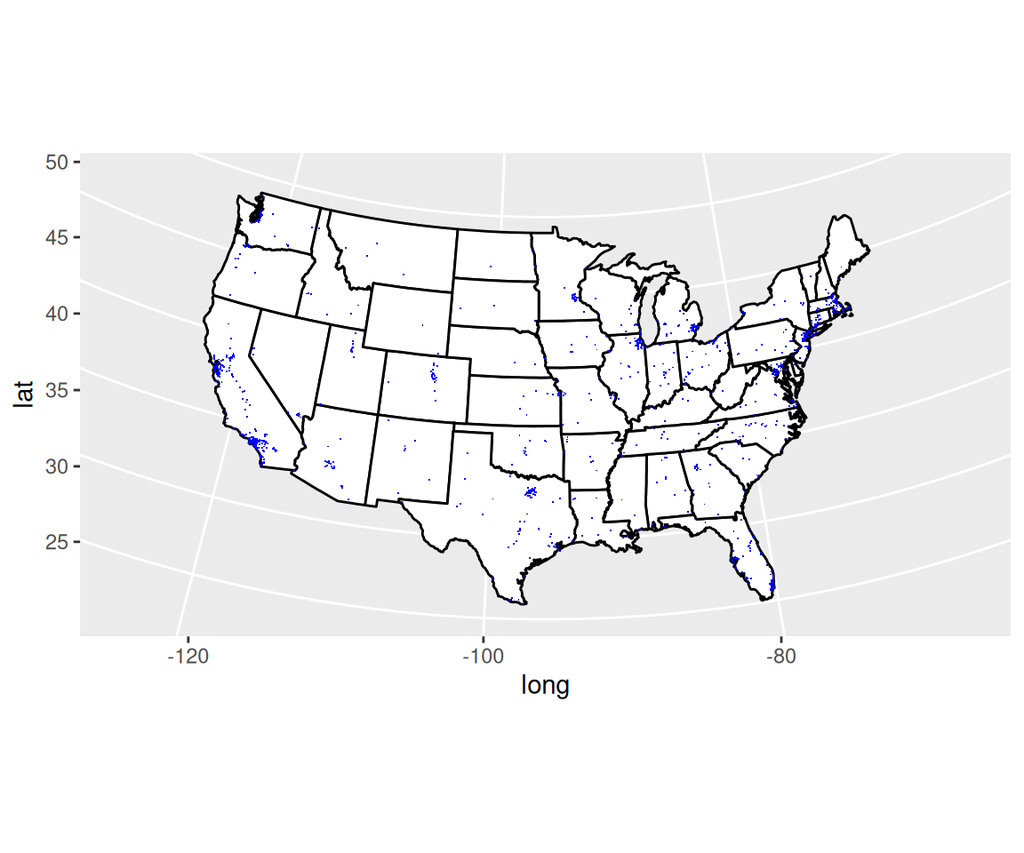

```r
us_states |>
  ggplot(aes(x = long, y = lat)) +
  geom_polygon(aes(group = group), fill = "white", color = "black") +
  geom_point(data = cities_lower48, aes(x = long, y = lat), color = "blue", shape = ".") +
  coord_map("albers", lat0 = 30, lat1 = 45)
```

## Maps that Include Alaska and Hawaii (1/2)

```r
usmap::plot_usmap(regions = "states")
```

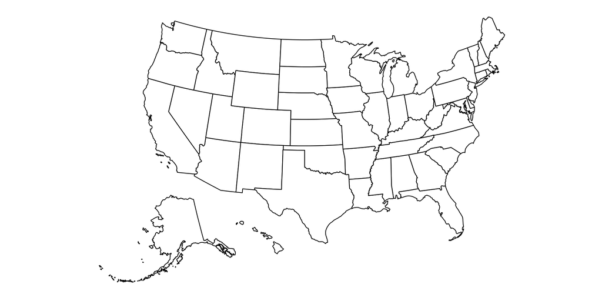

## Maps that Include Alaska and Hawaii (2/2)

### the `usmap::plot_usmap()` function returns a *ggplot object*

```r
plot_usmap(regions = "states") +
  labs(title = "US States")
```

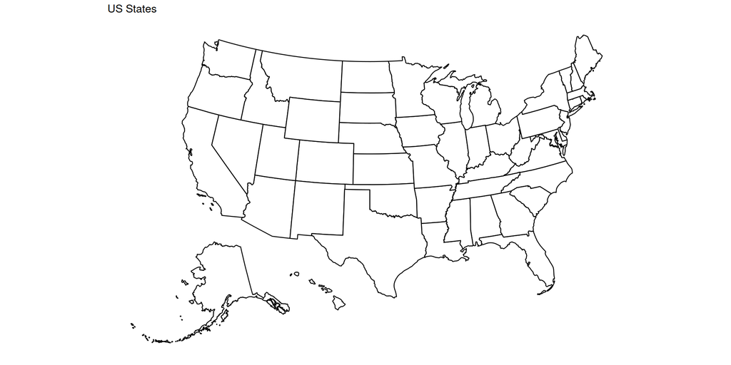

## Inspect the `us_map()` Data Frame

### Note, we do not have a data frame with latitude and longitude columns

```r
state_df <- us_map()
state_df
```

| fips | abbr | full | geom |
| --- | --- | --- | --- |
| 02 | AK | Alaska |  |
| 01 | AL | Alabama |  |
| 05 | AR | Arkansas |  |
| 04 | AZ | Arizona |  |
| 06 | CA | California |  |
| 08 | CO | Colorado |  |
| 09 | CT | Connecticut |  |
| 11 | DC | District of Columbia |  |
| 10 | DE | Delaware |  |
| 12 | FL | Florida |  |

[output cut: 41 more lines]

## Adding Cities to the `usmap` Map

### A convenience method called `usmap_transform` can be used to add cities (or other points) to the map.

```r
us_cities_transformed <- usmap_transform(us_cities, input_names = c("long", "lat"))

plot_usmap() +
  geom_sf(data = us_cities_transformed, aes(size = pop, color = log10(pop)))
```

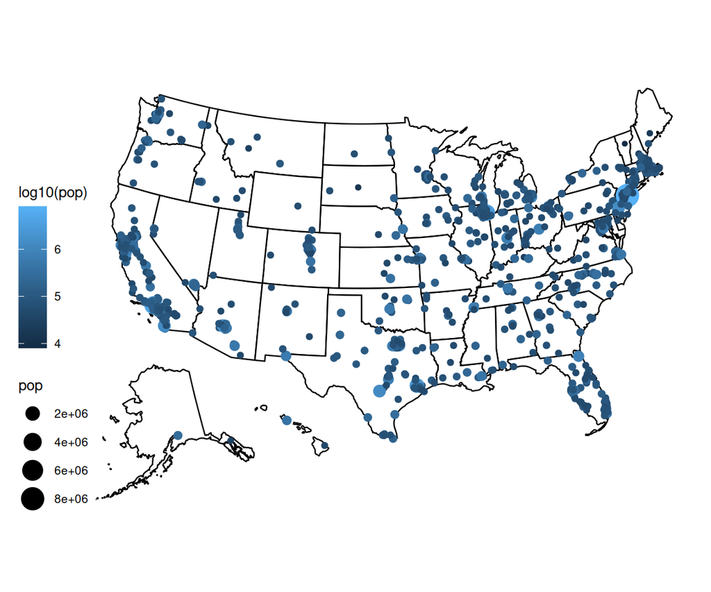

## Choropleth Maps (from **Claude.ai**)

### what is the origin of the word choropleth?

The word “choropleth” has an interesting etymology rooted in Greek. It’s a compound word formed from two Greek elements:

1. “Choro-” (χώρο-): This prefix comes from the Greek word “choros” (χώρος), which means “area” or “region.”
2. “-pleth” (-πλήθ): This suffix is derived from the Greek word “plethos” (πλῆθος), meaning “multitude” or “quantity.”

When combined, these elements create “choropleth,” which essentially means “area quantity” or “region value.” This name aptly describes the nature of choropleth maps, which display quantities or values across different geographic areas.

The term “choropleth” was coined in 1938 by John Kirtland Wright, an American geographer. Wright introduced this term in his doctoral dissertation at Harvard University, titled “Notes on Statistical Mapping, With Special Reference to the Mapping of Population Phenomena.”

This relatively recent coinage explains why the term might seem unfamiliar to many people, despite the widespread use of choropleth maps in various fields today.

## Add a Choropleth Layer to the Map

### State Population Data

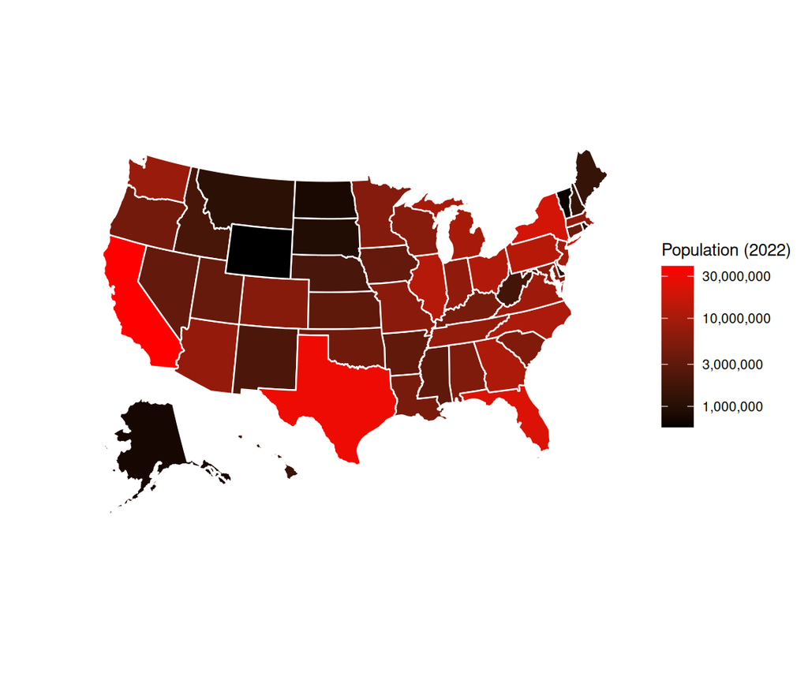

```r
plot_usmap(data = statepop, values = "pop_2022", color = "white") +
  scale_fill_continuous(
    low = "black", high = "red",
    name = "Population (2022)",
    label = scales::comma,
    trans = "log10") +
  theme(legend.position = "right")
```

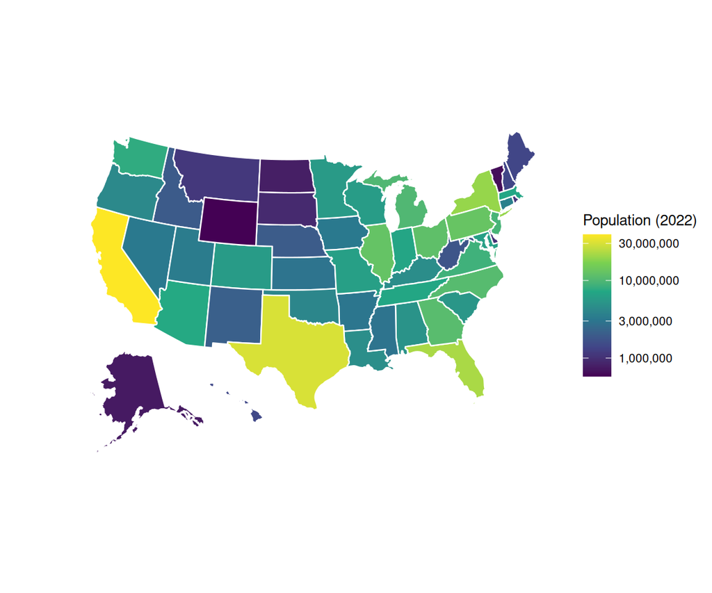

```r
plot_usmap(data = statepop, values = "pop_2022", color = "white") +
  scale_fill_viridis_c(
    name = "Population (2022)",
    label = scales::comma,
    trans = "log10") +
  theme(legend.position = "right")
```

## Working with Shapefiles

What are shapefiles?

From GitHub Copilot:

Shapefiles are a popular geospatial vector data format developed by Esri. They are used to store the geometric location and attribute information of geographic features. Shapefiles consist of several files with the same name but different extensions, such as .shp, .shx, .dbf, and .prj.

- The .shp file contains the geometry data, such as points, lines, or polygons, that represent the geographic features.
- The .shx file is an index file that helps speed up access to the geometry data.
- The .dbf file stores the attribute data associated with the geographic features, such as names, population counts, or other information.
- The .prj file contains the coordinate system information used to project the data onto a map.

## US Census

[Census Mapping Files](https://www.census.gov/geographies/mapping-files/time-series/geo/tiger-line-file.html)

## Loaing Shapefiles

```r
# Read the shapefile
ut_shapefile <- st_read("shapefiles/tl_2024_49_tract/tl_2024_49_tract.shp")
# Filter the shapefile to Salt Lake County (FIPS code: 035)
sl_county_sf <- ut_shapefile |>
  filter(COUNTYFP == "035")

sl_county_sf
```

|  | STATEFP | COUNTYFP | TRACTCE | GEOID | GEOIDFQ | NAME | NAMELSAD | MTFCC | FUNCSTAT | ALAND | AWATER | INTPTLAT | INTPTLON | geometry |
| --- | --- | --- | --- | --- | --- | --- | --- | --- | --- | --- | --- | --- | --- | --- |
| 1 | 49 | 035 | 115107 | 49035115107 | 1400000US49035115107 | 1151.07 | Census Tract 1151.07 | G5020 | S | 18883184 | 0 | +40.4704655 | -112.0594613 |  |
| 2 | 49 | 035 | 112831 | 49035112831 | 1400000US49035112831 | 1128.31 | Census Tract 1128.31 | G5020 | S | 7830902 | 0 | +40.4731895 | -111.8876896 |  |
| 3 | 49 | 035 | 113544 | 49035113544 | 1400000US49035113544 | 1135.44 | Census Tract 1135.44 | G5020 | S | 1880610 | 0 | +40.6781410 | -112.0362655 |  |
| 4 | 49 | 035 | 113025 | 49035113025 | 1400000US49035113025 | 1130.25 | Census Tract 1130.25 | G5020 | S | 2247443 | 0 | +40.5445415 | -111.9753884 |  |
| 5 | 49 | 035 | 113024 | 49035113024 | 1400000US49035113024 | 1130.24 | Census Tract 1130.24 | G5020 | S | 3648407 | 0 | +40.5526506 | -111.9661765 |  |
| 6 | 49 | 035 | 112815 | 49035112815 | 1400000US49035112815 | 1128.15 | Census Tract 1128.15 | G5020 | S | 40115768 | 43405 | +40.5280335 | -111.7889698 |  |
| 7 | 49 | 035 | 110800 | 49035110800 | 1400000US49035110800 | 1108 | Census Tract 1108 | G5020 | S | 3400677 | 0 | +40.6675888 | -111.8354938 |  |
| 8 | 49 | 035 | 112812 | 49035112812 | 1400000US49035112812 | 1128.12 | Census Tract 1128.12 | G5020 | S | 2858611 | 0 | +40.5631815 | -111.8735850 |  |
| 9 | 49 | 035 | 112616 | 49035112616 | 1400000US49035112616 | 1126.16 | Census Tract 1126.16 | G5020 | S | 2463363 | 0 | +40.5741034 | -111.8235164 |  |
| 10 | 49 | 035 | 112614 | 49035112614 | 1400000US49035112614 | 1126.14 | Census Tract 1126.14 | G5020 | S | 2559698 | 0 | +40.5988597 | -111.8199776 |  |

[output cut: 241 more lines]

## Using `ggplot` with Shapefiles

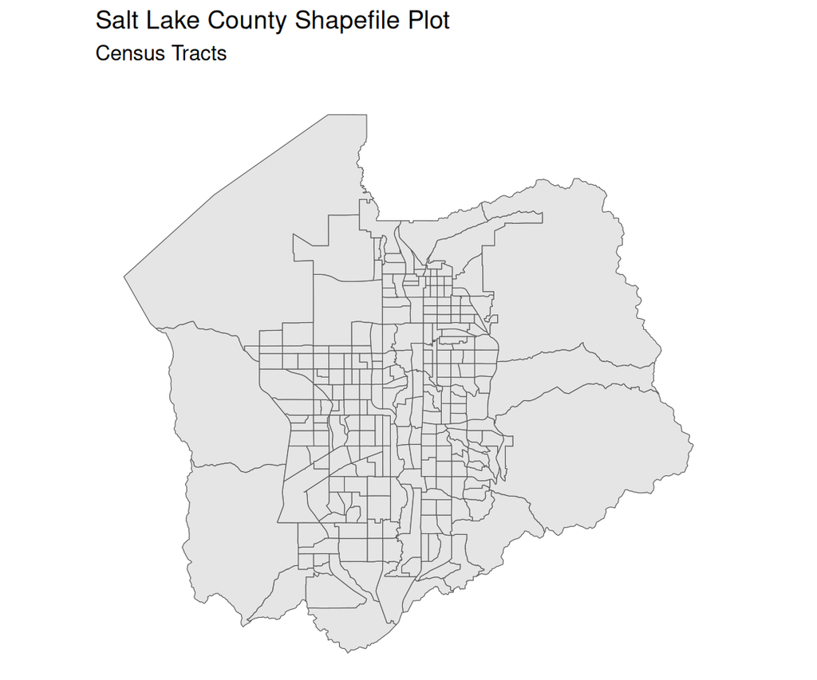

```r
sl_county_sf |>
  ggplot() +
  geom_sf() +
  labs(
    title = "Salt Lake County Shapefile Plot",
    subtitle = "Census Tracts
    ") +
  theme_void()
```

## Adding Data to the Shapefile

### Download median household income data from the 5-Year American Community Survey (ACS)

```r
# Load required libraries
library(tidycensus)

# Set your Census API key
# You need to sign up for an API key at http://api.census.gov/data/key_signup.html
# census_api_key("YOUR_API_KEY_HERE", install = TRUE)

# Define parameters
year <- 2022  # Use the most recent year available
state <- "UT"
county <- "Salt Lake"

# Get median household income data
salt_lake_income <- get_acs(
  geography = "tract",
  variables = "B19013_001",  # Median household income variable
  state = state,
  county = county,
  year = year,
  survey = "acs5" # 5-year estimates
)

# View the data
salt_lake_income
```

| GEOID | NAME | variable | estimate | moe |
| --- | --- | --- | --- | --- |
| 49035100100 | Census Tract 1001; Salt Lake County; Utah | B19013_001 | 87706 | 13571 |
| 49035100200 | Census Tract 1002; Salt Lake County; Utah | B19013_001 | 164000 | 25573 |
| 49035100306 | Census Tract 1003.06; Salt Lake County; Utah | B19013_001 | 62066 | 5255 |
| 49035100307 | Census Tract 1003.07; Salt Lake County; Utah | B19013_001 | 95302 | 15949 |
| 49035100308 | Census Tract 1003.08; Salt Lake County; Utah | B19013_001 | 56311 | 8294 |
| 49035100500 | Census Tract 1005; Salt Lake County; Utah | B19013_001 | 69060 | 7999 |
| 49035100600 | Census Tract 1006; Salt Lake County; Utah | B19013_001 | 69618 | 15237 |
| 49035100700 | Census Tract 1007; Salt Lake County; Utah | B19013_001 | 67150 | 8478 |
| 49035100800 | Census Tract 1008; Salt Lake County; Utah | B19013_001 | 66992 | 11360 |
| 49035101000 | Census Tract 1010; Salt Lake County; Utah | B19013_001 | 108274 | 42146 |

[output cut: 241 more lines]

## Joining Two Data Frames: Example 1

```r
# Create two data frames
df1 <- tibble(id = c(1, 2, 3), value = c(10, 20, 30))
df2 <- tibble(id = c(1, 2, 3), value = c(100, 200, 300))

# Join the data frames
df_new <- df1 |>
  left_join(df2, by = "id")

df1
```

| id | value |
| --- | --- |
| 1 | 10 |
| 2 | 20 |
| 3 | 30 |

```r
df2
```

| id | value |
| --- | --- |
| 1 | 100 |
| 2 | 200 |
| 3 | 300 |

```r
df_new
```

| id | value.x | value.y |
| --- | --- | --- |
| 1 | 10 | 100 |
| 2 | 20 | 200 |
| 3 | 30 | 300 |

## Joining Two Data Frames: Example 2

```r
# Create two data frames with different IDs
df1 <- tibble(id = c(1, 2, 3), value = c(10, 20, 30))
df2 <- tibble(id = c(2, 3, 4), value = c(100, 200, 300))

# Join the data frames
df_new <- df1 |>
  left_join(df2, by = "id")

df1
```

| id | value |
| --- | --- |
| 1 | 10 |
| 2 | 20 |
| 3 | 30 |

```r
df2
```

| id | value |
| --- | --- |
| 2 | 100 |
| 3 | 200 |
| 4 | 300 |

```r
df_new
```

| id | value.x | value.y |
| --- | --- | --- |
| 1 | 10 | NA |
| 2 | 20 | 100 |
| 3 | 30 | 200 |

## Joining Two Data Frames: Example 3

```r
# Create two data frames with different IDs
df1 <- tibble(id = c(1, 2, 3), value = c(10, 20, 30))
df2 <- tibble(id = c(2, 3, 4), value = c(100, 200, 300))

# Join the data frames
df_new <- df1 |>
  inner_join(df2, by = "id")

df1
```

| id | value |
| --- | --- |
| 1 | 10 |
| 2 | 20 |
| 3 | 30 |

```r
df2
```

| id | value |
| --- | --- |
| 2 | 100 |
| 3 | 200 |
| 4 | 300 |

```r
df_new
```

| id | value.x | value.y |
| --- | --- | --- |
| 2 | 20 | 100 |
| 3 | 30 | 200 |

## Joining Two Data Frames: Example 4

```r
# Create two data frames with different IDs
df1 <- tibble(id = c(1, 2, 3), value = c(10, 20, 30))
df2 <- tibble(id = c(2, 3, 4), value = c(100, 200, 300))

# Join the data frames
df_new <- df1 |>
  full_join(df2, by = "id")

df1
```

| id | value |
| --- | --- |
| 1 | 10 |
| 2 | 20 |
| 3 | 30 |

```r
df2
```

| id | value |
| --- | --- |
| 2 | 100 |
| 3 | 200 |
| 4 | 300 |

```r
df_new
```

| id | value.x | value.y |
| --- | --- | --- |
| 1 | 10 | NA |
| 2 | 20 | 100 |
| 3 | 30 | 200 |
| 4 | NA | 300 |

## Join the Data to the Shapefile

```r
sl_county_tracts_income <- sl_county_sf |>
  left_join(salt_lake_income, by = "GEOID")

sl_county_tracts_income
```

| STATEFP | COUNTYFP | TRACTCE | GEOID | GEOIDFQ | NAME.x | NAMELSAD | MTFCC | FUNCSTAT | ALAND | AWATER | INTPTLAT | INTPTLON | NAME.y | variable | estimate | moe | geometry |
| --- | --- | --- | --- | --- | --- | --- | --- | --- | --- | --- | --- | --- | --- | --- | --- | --- | --- |
| 49 | 035 | 115107 | 49035115107 | 1400000US49035115107 | 1151.07 | Census Tract 1151.07 | G5020 | S | 18883184 | 0 | +40.4704655 | -112.0594613 | Census Tract 1151.07; Salt Lake County; Utah | B19013_001 | 151263 | 14771 |  |
| 49 | 035 | 112831 | 49035112831 | 1400000US49035112831 | 1128.31 | Census Tract 1128.31 | G5020 | S | 7830902 | 0 | +40.4731895 | -111.8876896 | Census Tract 1128.31; Salt Lake County; Utah | B19013_001 | 134265 | 35440 |  |
| 49 | 035 | 113544 | 49035113544 | 1400000US49035113544 | 1135.44 | Census Tract 1135.44 | G5020 | S | 1880610 | 0 | +40.6781410 | -112.0362655 | Census Tract 1135.44; Salt Lake County; Utah | B19013_001 | 118716 | 11578 |  |
| 49 | 035 | 113025 | 49035113025 | 1400000US49035113025 | 1130.25 | Census Tract 1130.25 | G5020 | S | 2247443 | 0 | +40.5445415 | -111.9753884 | Census Tract 1130.25; Salt Lake County; Utah | B19013_001 | 110687 | 8967 |  |
| 49 | 035 | 113024 | 49035113024 | 1400000US49035113024 | 1130.24 | Census Tract 1130.24 | G5020 | S | 3648407 | 0 | +40.5526506 | -111.9661765 | Census Tract 1130.24; Salt Lake County; Utah | B19013_001 | 143043 | 26226 |  |
| 49 | 035 | 112815 | 49035112815 | 1400000US49035112815 | 1128.15 | Census Tract 1128.15 | G5020 | S | 40115768 | 43405 | +40.5280335 | -111.7889698 | Census Tract 1128.15; Salt Lake County; Utah | B19013_001 | 164028 | 35808 |  |
| 49 | 035 | 110800 | 49035110800 | 1400000US49035110800 | 1108 | Census Tract 1108 | G5020 | S | 3400677 | 0 | +40.6675888 | -111.8354938 | Census Tract 1108; Salt Lake County; Utah | B19013_001 | 67083 | 15275 |  |
| 49 | 035 | 112812 | 49035112812 | 1400000US49035112812 | 1128.12 | Census Tract 1128.12 | G5020 | S | 2858611 | 0 | +40.5631815 | -111.8735850 | Census Tract 1128.12; Salt Lake County; Utah | B19013_001 | 91278 | 12082 |  |
| 49 | 035 | 112616 | 49035112616 | 1400000US49035112616 | 1126.16 | Census Tract 1126.16 | G5020 | S | 2463363 | 0 | +40.5741034 | -111.8235164 | Census Tract 1126.16; Salt Lake County; Utah | B19013_001 | 134615 | 18342 |  |
| 49 | 035 | 112614 | 49035112614 | 1400000US49035112614 | 1126.14 | Census Tract 1126.14 | G5020 | S | 2559698 | 0 | +40.5988597 | -111.8199776 | Census Tract 1126.14; Salt Lake County; Utah | B19013_001 | 153393 | 36565 |  |

[output cut: 241 more lines]

## Create a Choropleth Map

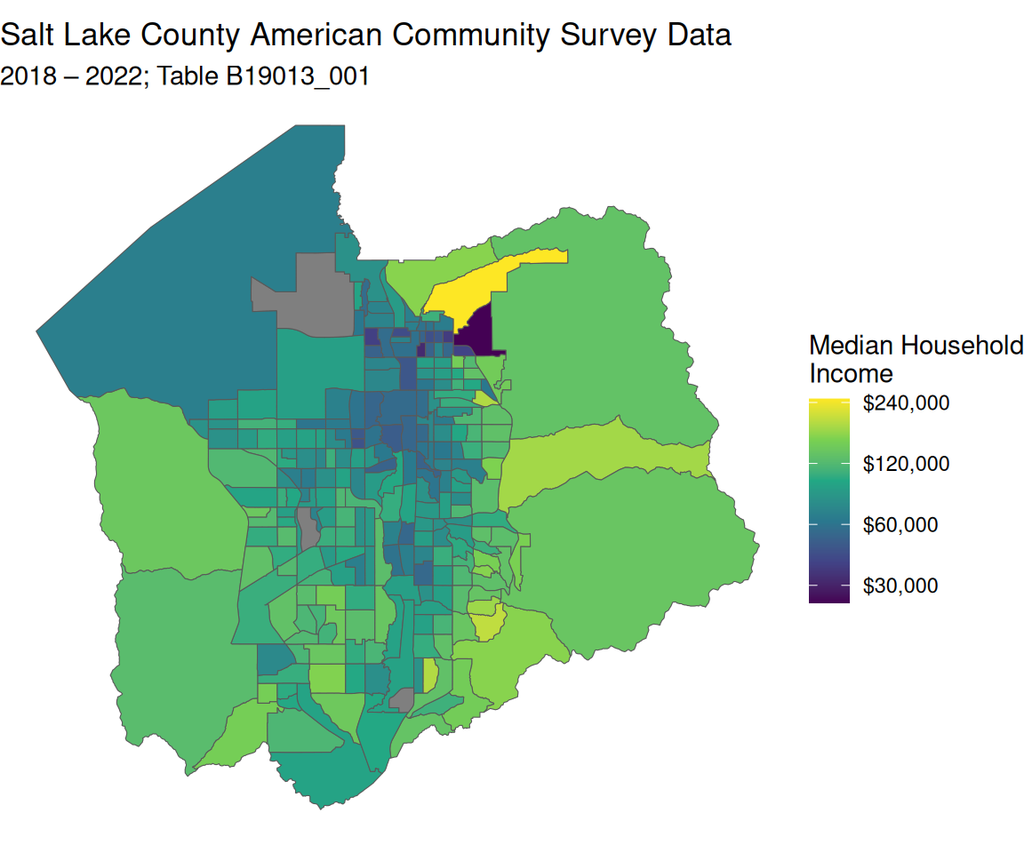

```r
sl_county_tracts_income |>
  ggplot() +
  geom_sf(aes(fill = estimate)) +
  scale_fill_viridis_c(
    name = "Median Household\nIncome",
    label = scales::dollar,
    trans = "log10",
    breaks = c(30000, 60000, 120000, 240000),
  ) +
  theme_minimal() +
  labs(
    title = "Salt Lake County American Community Survey Data",
    subtitle = "2018 \u2013 2022; Table B19013_001"
    ) +
  theme_void()
```

## Redlining (SLC)

[Redlining Map of Salt Lake City, Utah](https://www.docsteach.org/documents/document/redlining-map-of-salt-lake-city-utah)

[figure not shown]

ca. 1933 - 1939

## Maps Assignment

For this assignment, we will summarize the mean debt of graduate student loans per state and display the data on a map of the U.S.

You will need the College Scorecard dataset Most-Recent-Cohorts-Field-of-Study.csv and the Most-Recent-Cohorts-Institution.csv files.

We will go through the following steps in class:

- Add directory information for each institution to the College Scorecard data frame
- Clean the data frame by removing the “Privacy Supressed” fields and converting needed columns from text to numbers
- Summarize the total debt by state
- Decide what additional information is needed to join the summary data to the map data files
- Create a choropleth map

Links:

[College Scorecard Data](https://collegescorecard.ed.gov/data/)

[College Scorecard Documentation](https://collegescorecard.ed.gov/data/documentation/)

Download the “Most Recent Data by Field of Study.zip” and the “Data Dictionary”

## College Scorecard Datasets

```r
college_scorecard_field_of_study <- read_csv("datasets/College_Scorecard_Raw_Data_06102024/Most-Recent-Cohorts-Field-of-Study.csv")
```

```r
dim(college_scorecard_field_of_study)
```

```
[1] 229188    174
```

```r
college_scorecard_institution <- read_csv("datasets/College_Scorecard_Raw_Data_06102024/Most-Recent-Cohorts-Institution.csv")
```

```r
dim(college_scorecard_institution)
```

```
[1] 6484 3305
```